# IODS course project

Annukka Puotiniemi

# 1. About the project

## Introduction to Open Data Science

This 7-week course, as described in Kimmo Vehkalahti’s blog, is

*open for everyone willing to learn how to use RStudio, R Markdown and GitHub (state-of-the-art tools of data science) to visualise and analyse open data with multivariate statistical methods following principles and practices of reproducible research*

The course sounds exciting enough for me to cha(lle)nge my plans and become a data scientist!

[Annukka’s GitHub repository](https://github.com/msnxt/IODS-project)

# 2. Regression and model validation

*Below are all the codes, my interpretations and explanations for this week’s data analysis exercises.*

*A brief note about data wrangling that preceded this diary entry. After I filtered my dataset to exclude rows that had zero values for points, almost the whole dataset printed NA values. I found the following solution in StackOverflow:*

a_dataset <- analysis_dataset[apply(analysis_dataset!=0, 1, all),]

*I now have the correct number of observations and variables, but this method would exclude all other zero rows too I think…*

To read the previously wrangled data from my local folder into R:

```r
mydata <- read.csv("learning2014.csv")
```

The dataset is a combination of certain variables from a survey dataset. The survey examined the relationship between learning approaches and the achievements of students. All combination variables were scaled to the original scales. Observations where the exam points variable is zero (student did not sit the exam) were excluded to remove outliers. The (combination) variables included are:  
- gender  
- age  
- attitude (Global attitude toward statistics)  
- deep (measures deep learning)  
- stra (measures strategic learning)  
- surf (measures surface learning)  
- points (points from the exam)

To begin the graphical overview of the data,I initialized the plot with data and aesthetic mappings, including colours by the variable gender, and showed summaries of the variables in the data:

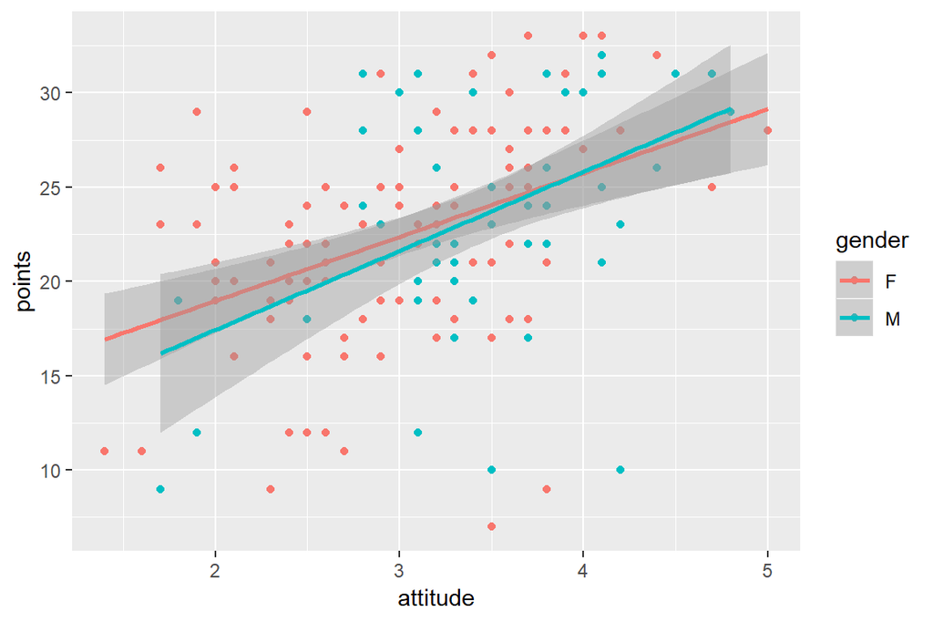

```r
library(ggplot2)
p1 <- ggplot(mydata, aes(x = attitude, y = points, col = gender))
p2 <- p1 + geom_point()
p3 <- p2 + geom_smooth(method = "lm")
p3
```

Summary of the data is presented below.

```r
summary(mydata)
```

```
##        X          gender       age           attitude          deep
##  Min.   :  1.00   F:110   Min.   :17.00   Min.   :1.400   Min.   :1.583
##  1st Qu.: 44.25   M: 56   1st Qu.:21.00   1st Qu.:2.600   1st Qu.:3.333
##  Median : 87.50           Median :22.00   Median :3.200   Median :3.667
##  Mean   : 90.13           Mean   :25.51   Mean   :3.143   Mean   :3.680
##  3rd Qu.:136.75           3rd Qu.:27.00   3rd Qu.:3.700   3rd Qu.:4.083
##  Max.   :183.00           Max.   :55.00   Max.   :5.000   Max.   :4.917
##
##       stra            surf           points           X.1
##  Min.   :1.250   Min.   :1.583   Min.   : 7.00   Min.   :22.72
##  1st Qu.:2.625   1st Qu.:2.417   1st Qu.:19.00   1st Qu.:22.72
##  Median :3.188   Median :2.833   Median :23.00   Median :22.72
##  Mean   :3.121   Mean   :2.787   Mean   :22.72   Mean   :22.72
##  3rd Qu.:3.625   3rd Qu.:3.167   3rd Qu.:27.75   3rd Qu.:22.72
##  Max.   :5.000   Max.   :4.333   Max.   :33.00   Max.   :22.72
##                                                  NA's   :165
##       X.2
##  Min.   :11.36
##  1st Qu.:11.36
##  Median :11.36
##  Mean   :11.36
##  3rd Qu.:11.36
##  Max.   :11.36
##  NA's   :165
```

The gender split of the respondents was 110 female and 56 male. Their ages ranged from 17 to 55, with an average age 25.51. The variable “attitude” is a combination variable of 10 variables and measures a global attitude toward statistics. The next three variables, deep approach (deep), strategic approach (stra) and surface approach (surf) are likewise combinatory variables and they have been scaled to the original scales. The average of attitude is 3.143, deep 3.68, strategic 3.121 and surface 2.787. The variable points shows the number of points the student achieved in an exam, and the average was 22.72.

For my model I chose the variables `age`, `attitude` and `stra` as explanatory variables and the target variable is points. A summary of the fitted model is shown below.

```r
my_model <- lm(points ~ age + attitude + stra, data = mydata)
summary(my_model)
```

```
##
## Call:
## lm(formula = points ~ age + attitude + stra, data = mydata)
##
## Residuals:
##      Min       1Q   Median       3Q      Max
## -18.1149  -3.2003   0.3303   3.4129  10.7599
##
## Coefficients:
##             Estimate Std. Error t value Pr(>|t|)
## (Intercept) 10.89543    2.64834   4.114 6.17e-05 ***
## age         -0.08822    0.05302  -1.664   0.0981 .
## attitude     3.48077    0.56220   6.191 4.72e-09 ***
## stra         1.00371    0.53434   1.878   0.0621 .
## ---
## Signif. codes:  0 '***' 0.001 '**' 0.01 '*' 0.05 '.' 0.1 ' ' 1
##
## Residual standard error: 5.26 on 162 degrees of freedom
## Multiple R-squared:  0.2182, Adjusted R-squared:  0.2037
## F-statistic: 15.07 on 3 and 162 DF,  p-value: 1.07e-08
```

The p-values for the coefficients indicate whether these relationships are statistically significant. The model above shows the variables with their significance levels. Age and strategic have a significance level of approximately 0.1 and 0.06 respectively, which, while being larger than the more or less generally accepted level of 0.05, still shows some significance. However, as keeping variables that are not statistically very significant can reduce the model’s precision, I will therefore only include `attitude` (with its significance code of 0) and `stra` (with the significance level that is very close to 0.05) in my re-fitted model. The new model is shown below.

```r
my_model <- lm(points ~ attitude + stra, data = mydata)
summary(my_model)
```

```
##
## Call:
## lm(formula = points ~ attitude + stra, data = mydata)
##
## Residuals:
##      Min       1Q   Median       3Q      Max
## -17.6436  -3.3113   0.5575   3.7928  10.9295
##
## Coefficients:
##             Estimate Std. Error t value Pr(>|t|)
## (Intercept)   8.9729     2.3959   3.745  0.00025 ***
## attitude      3.4658     0.5652   6.132 6.31e-09 ***
## stra          0.9137     0.5345   1.709  0.08927 .
## ---
## Signif. codes:  0 '***' 0.001 '**' 0.01 '*' 0.05 '.' 0.1 ' ' 1
##
## Residual standard error: 5.289 on 163 degrees of freedom
## Multiple R-squared:  0.2048, Adjusted R-squared:  0.1951
## F-statistic: 20.99 on 2 and 163 DF,  p-value: 7.734e-09
```

The multiple regression model makes the following assumptions:  
1. The relationship between the independent and dependent variables is linear.  
2. The errors between observed and predicted values should be normally distributed.  
3. The data has no multicollinearity (this happens when the independent variables correlate too highly with each other).  
4. Homoscedasticity, a.k.a. homogeneity of variance.

The validity of these model assumptions can be explored by analyzing the residuals of the model, as in the plots shown below.

To produce the diagnostic plots Residuals vs Fitted values (plot 1), Normal QQ-plot (plot 2) and Residuals vs Leverage (plot 5):

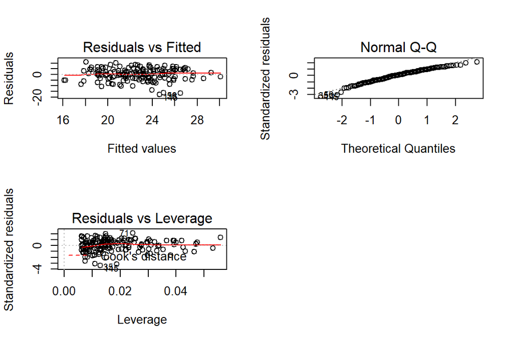

```r
par(mfrow = c(2,2))
plot(my_model, which = c(1:2, 5))
```

The normality assumption (assumption 2. above) can be explored by analyzing the Q-Q plot. The fit to the normality assumption is reasonably good in this case.

The homoscedasticity assumption (assumption 4.) implies that the size of the errors should not depend on the explanatory variables. This can be explored with the residuals vs fitted plot. As we can see from the first plot, there is a reasonably random placement of plots with no discernible pattern, and therefore the assumption is valid.

The last plot, residuals vs leverage, can help determine which observations have an unusually high impact on the model (assumption 3.). As we can observe from the plot, there is no single outlier that stands out, and therefore we can conclude that this assumption is valid.

After this graphical exploration we can conclude that the validity of the model assumptions is good.

# 3. Logistic regression

Moving on from linear regression, this week we will look at logictic regression. It is a method well suited for predicting and classifying data through probabilities. This week we will look at the concept of odds ratio (OR). We will also take a look at cross-validation, and learn about splitting the data into a training set and a test set.

*Below are all the codes, my interpretations and explanations for this week’s data analysis exercises.*

The data for this exercise was downloaded from the UC Irvine Machine Learning Repository.

The data are two student performance data sets that approach student achievement in secondary education of two schools in Portugal. The data variables include student grades, as well as demographic, social and school related features. The data was collated using school reports and questionnaires. The two datasets that analyze the performance in two distinct subjects: Mathematics (mat) and Portuguese language (por).

In the data wrangling exercise (which can be found in my [GitHub repository](https://github.com/msnxt/IODS-project/blob/master/create_alc.R)) performed prior to this report, the two data sets were combined using a number of variables as student identifiers. Only the students present in both data sets were kept. Next, the average of the answers related to weekday and weekend alcohol consumption was taken to create a new variable ‘alc_use’. Then ‘alc_use’ was used to create a new logical column ‘high_use’ (TRUE for students whose ‘alc_use’ is greater than 2 and FALSE otherwise).

Citation:  
P. Cortez and A. Silva. Using Data Mining to Predict Secondary School Student Performance. In A. Brito and J. Teixeira Eds., Proceedings of 5th FUture BUsiness TEChnology Conference (FUBUTEC 2008) pp. 5-12, Porto, Portugal, April, 2008, EUROSIS, ISBN 978-9077381-39-7.

## Part 1 - General Housekeeping

For the first part of this analysis I created a new RMarkdown file and save it as an empty file named ‘chapter3.Rmd’. Then I included this file as a child file in my ‘index.Rmd’ file, and as a result you are now reading this.

## Part 2 - The Data Set

I read the joined student alcohol consumption data into R from my local folder.

```r
alc <- read.table("create_alc.csv", sep = "," , header=TRUE)
```

Next, I printed out the names of the variables in the data.

```r
colnames(alc)
```

```
##  [1] "school"     "sex"        "age"        "address"    "famsize"
##  [6] "Pstatus"    "Medu"       "Fedu"       "Mjob"       "Fjob"
## [11] "reason"     "nursery"    "internet"   "guardian"   "traveltime"
## [16] "studytime"  "failures"   "schoolsup"  "famsup"     "paid"
## [21] "activities" "higher"     "romantic"   "famrel"     "freetime"
## [26] "goout"      "Dalc"       "Walc"       "health"     "absences"
## [31] "G1"         "G2"         "G3"         "alc_use"    "high_use"
```

The data set consists of 382 observations of 35 variables. The variables are a combination of numeric, nominal and binary attributes.

## Part 3 - Choosing Variables of Interest

For this part, in order to study the relationship between high or low alcohol consumption, I chose the following 4 variables from the data, including my personal hypothesis for each variable:  
1. `age` - I hypothesize that higher age will correlate with high alcohol consumption.  
2. `failures` - indicating the number of past class failures. My hypothesis is that a high number of failures correlates with high alcohol use.  
3. `famrel` - indicator for the quality of family relations. Better family relations will mean lower alcohol consumption and conversely worse relations will correlate with higher alcohol use.  
4. `absences` - number of school absences. A higher number of absences will relate to high alcohol consumption.

## Part 4 - Exploring the Variables

Next, I accessed some R packages that I will need shortly, and I also created a mini-dataset called `alc_dataset`. This mini-dataset will allow me to represent just the data I chose for my analysis.

Accessing packages dplyr and ggplot2:

```r
library(dplyr); library(ggplot2)
```

Creating `alc_dataset`:

```r
alc_use <- alc$alc_use
high_use <- alc$high_use
age <- alc$age
failures <- alc$failures
famrel <- alc$famrel
absences <- alc$absences
alc_dataset <- data.frame(alc_use, age, failures, famrel, absences)
summary(alc_dataset)
```

```
##     alc_use           age           failures          famrel
##  Min.   :1.000   Min.   :15.00   Min.   :0.0000   Min.   :1.000
##  1st Qu.:1.000   1st Qu.:16.00   1st Qu.:0.0000   1st Qu.:4.000
##  Median :1.500   Median :17.00   Median :0.0000   Median :4.000
##  Mean   :1.889   Mean   :16.59   Mean   :0.2016   Mean   :3.937
##  3rd Qu.:2.500   3rd Qu.:17.00   3rd Qu.:0.0000   3rd Qu.:5.000
##  Max.   :5.000   Max.   :22.00   Max.   :3.0000   Max.   :5.000
##     absences
##  Min.   : 0.0
##  1st Qu.: 1.0
##  Median : 3.0
##  Mean   : 4.5
##  3rd Qu.: 6.0
##  Max.   :45.0
```

Above is the initial numeric summary for all the variables that I chose. This does not tell us anything when it comes to the relationships between the variables, but it is a nice neat summary of the distribution of each variable.

Let’s look at a simple plot that illustrates `high_use`.

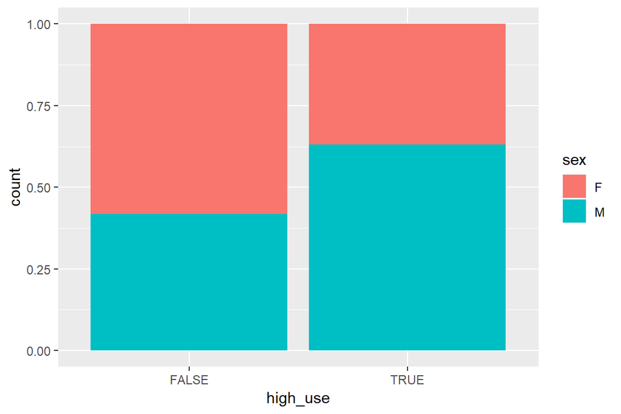

```r
ggplot(alc, aes(x = high_use, fill = sex)) +
  geom_bar(position = "fill")
```

Unsurprisingly, most high users of alcohol in this dataset were male.

Before we get into the logistic regression in part 5 below, let’s look at some numerical (summaries by group using the pipe operator) and graphical (box plot) representations of the data. Here, I will compare the variable `high_use` with variables `age`, `failures`, `famrel`, and `absences`.

### Variable `age`

```r
alc %>% group_by(sex, high_use) %>% summarise(count = n(), mean_age = mean(age))
```

```
## # A tibble: 4 x 4
## # Groups:   sex [?]
##   sex   high_use count mean_age
##   <fct> <lgl>    <int>    <dbl>
## 1 F     FALSE      156     16.6
## 2 F     TRUE        42     16.5
## 3 M     FALSE      112     16.3
## 4 M     TRUE        72     17.0
```

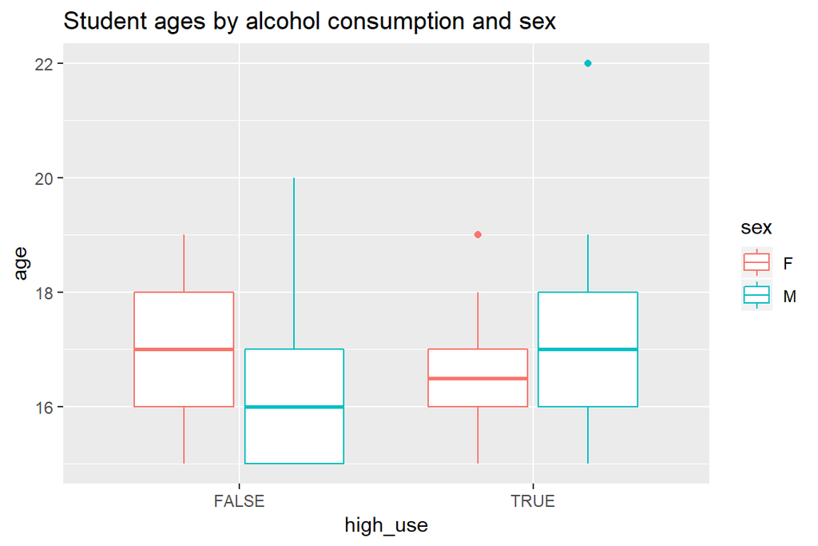

```r
# barplot
g1a <- ggplot(data=alc, aes(x=age, y=consumption)) +
geom_bar(stat="identity")

# initialise a plot of high_use and age
g1 <- ggplot(alc, aes(x = high_use, y = age, col = sex))

 # define the plot as a boxplot and draw it
g1 + geom_boxplot() + ggtitle("Student ages by alcohol consumption and sex")
```

The numerical representation and the plot above quite clearly shows that my first hypothesis, concerning age, was largely rubbish. Moving on!

### Variable `failures`

```r
alc %>% group_by(sex, high_use) %>% summarise(count = n(), mean_failures = mean(failures))
```

```
## # A tibble: 4 x 4
## # Groups:   sex [?]
##   sex   high_use count mean_failures
##   <fct> <lgl>    <int>         <dbl>
## 1 F     FALSE      156         0.115
## 2 F     TRUE        42         0.286
## 3 M     FALSE      112         0.179
## 4 M     TRUE        72         0.375
```

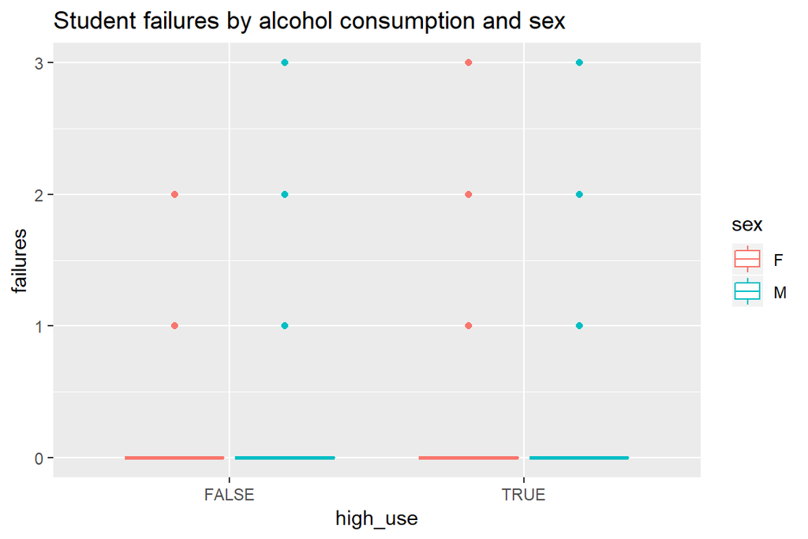

```r
# initialise a plot of high_use and failures
g2 <- ggplot(alc, aes(x = high_use, y = failures, col = sex))

 # define the plot as a boxplot and draw it
 g2 + geom_boxplot() + ggtitle("Student failures by alcohol consumption and sex")
```

The analysis of `failures` shows that, regardless of the rather useless box plot, my hypothesis was in the right track. In both males and females, the mean failures of those having high alcohol use was considerably more than the mean failures of those not having high alcohol use. In males, the difference between mean failures of high and low alcohol users, at 0.196, is higher than the difference, 0.171, in females. This is starting to point toward the fact that perhaps I should have hypothesized that being male is a factor in high alcohol use.

### Variable `famrel`

```r
alc %>% group_by(sex, high_use) %>% summarise(count = n(), mean_famrel = mean(famrel))
```

```
## # A tibble: 4 x 4
## # Groups:   sex [?]
##   sex   high_use count mean_famrel
##   <fct> <lgl>    <int>       <dbl>
## 1 F     FALSE      156        3.91
## 2 F     TRUE        42        3.76
## 3 M     FALSE      112        4.13
## 4 M     TRUE        72        3.79
```

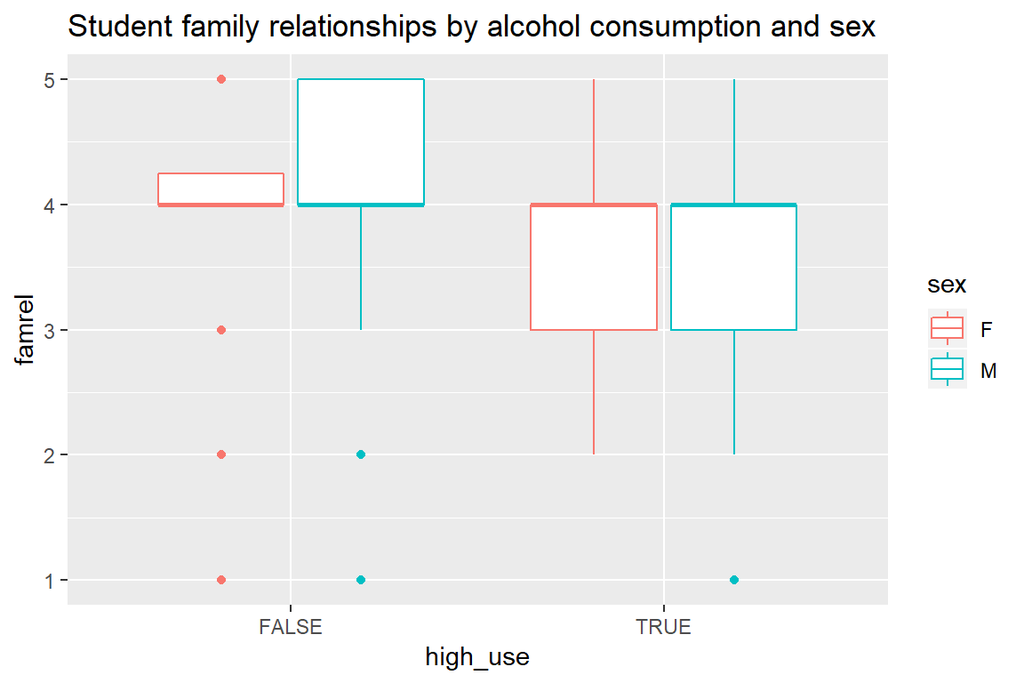

```r
# initialise a plot of high_use and family relationships
g3 <- ggplot(alc, aes(x = high_use, y = famrel, col = sex))

 # define the plot as a boxplot and draw it
 g3 + geom_boxplot() + ggtitle("Student family relationships by alcohol consumption and sex")
```

The analysis of `famrel` also shows that my hypothesis was not incorrect. In both sexes, the mean family relationships score of those having high alcohol use was lower than the mean failures of those not having high alcohol use. Here, a difference between the sexes is also evident, albeit in a manner rather different from the variable `failures`. The mean family relationship scores for the high alcohol users in both sexes was about the same, whereas, rather interrestingly, the family relationships score was better for males in the low alcohol use group.

### Variable `absences`

```r
alc %>% group_by(sex, high_use) %>% summarise(count = n(), mean_absences = mean(absences))
```

```
## # A tibble: 4 x 4
## # Groups:   sex [?]
##   sex   high_use count mean_absences
##   <fct> <lgl>    <int>         <dbl>
## 1 F     FALSE      156          4.22
## 2 F     TRUE        42          6.79
## 3 M     FALSE      112          2.98
## 4 M     TRUE        72          6.12
```

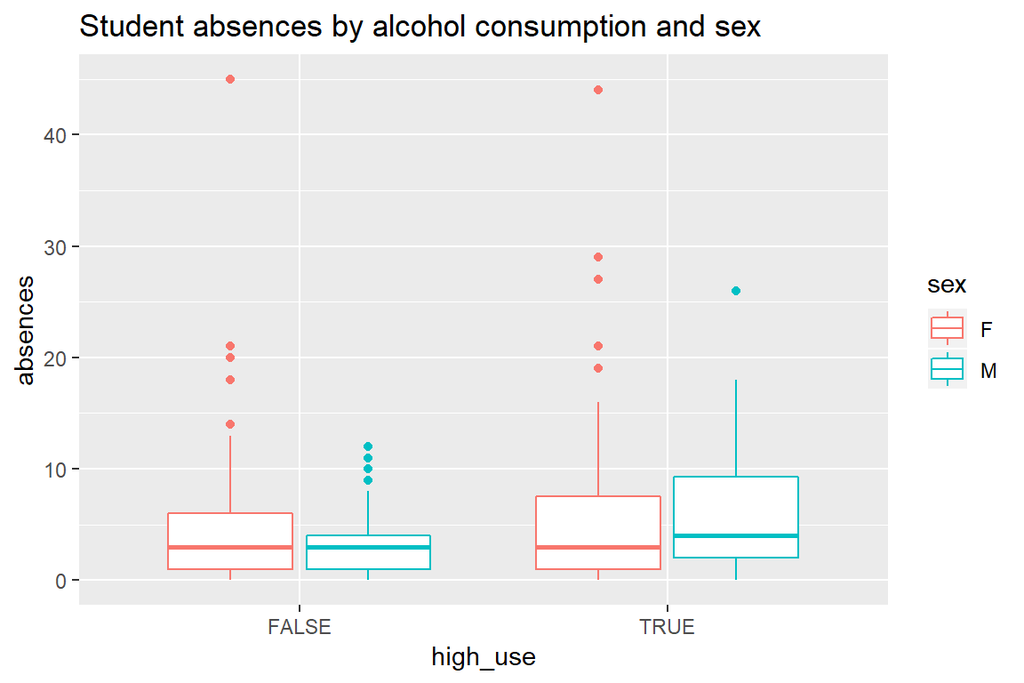

```r
# initialise a plot of high_use and absences
g4 <- ggplot(alc, aes(x = high_use, y = absences, col = sex))

 # define the plot as a boxplot and draw it
 g4 + geom_boxplot() + ggtitle("Student absences by alcohol consumption and sex")
```

The analysis of `absences` shows that my hypothesis was correct: a higher number of absences does indeed correlate with high alcohol consumption. Again, the differences between the sexes in striking. The mean absences for both male and female high alcohol users are around the same ballpark, but the mean absence figures for low alcohol users differs dramatically between the sexes: 2.982 for the males and 4.224 for the females. This not only indicates that females generally have more school absences, but also that in males the introduction of high alcohol use dramatically increases the mean number of absences.

## Part 5 - Logistic Regression

Next, I will use logistic regression to explore the relationship between my chosen variables and the binary variable `high_use`. This is done by using `glm()` to fit a logictic regression model. I will also print a summary of the model and I will use `coef()` to print out the coefficients of my model.

```r
model <- glm(high_use ~ age + failures + famrel + absences, data = alc, family = "binomial")
summary(model)
```

```
##
## Call:
## glm(formula = high_use ~ age + failures + famrel + absences,
##     family = "binomial", data = alc)
##
## Deviance Residuals:
##     Min       1Q   Median       3Q      Max
## -2.2478  -0.7937  -0.6783   1.1488   1.9908
##
## Coefficients:
##             Estimate Std. Error z value Pr(>|z|)
## (Intercept) -2.73938    1.73621  -1.578 0.114614
## age          0.13990    0.10248   1.365 0.172213
## failures     0.43635    0.18747   2.328 0.019933 *
## famrel      -0.23849    0.12558  -1.899 0.057560 .
## absences     0.08040    0.02259   3.560 0.000371 ***
## ---
## Signif. codes:  0 '***' 0.001 '**' 0.01 '*' 0.05 '.' 0.1 ' ' 1
##
## (Dispersion parameter for binomial family taken to be 1)
##
##     Null deviance: 465.68  on 381  degrees of freedom
## Residual deviance: 434.98  on 377  degrees of freedom
## AIC: 444.98
##
## Number of Fisher Scoring iterations: 4
```

```r
coef(model)
```

```
## (Intercept)         age    failures      famrel    absences
## -2.73937782  0.13989709  0.43634997 -0.23848933  0.08040375
```

As I observed above, it seems that `sex` has a statistical significance, and I am fitting my model again. This time I will include `sex` and exclude `age`.

```r
model <- glm(high_use ~ sex + failures + famrel + absences, data = alc, family = "binomial")
summary(model)
```

```
##
## Call:
## glm(formula = high_use ~ sex + failures + famrel + absences,
##     family = "binomial", data = alc)
##
## Deviance Residuals:
##     Min       1Q   Median       3Q      Max
## -2.1174  -0.8376  -0.5867   1.0091   2.1557
##
## Coefficients:
##             Estimate Std. Error z value Pr(>|z|)
## (Intercept) -0.83877    0.53446  -1.569   0.1166
## sexM         0.99120    0.24540   4.039 5.37e-05 ***
## failures     0.42458    0.18854   2.252   0.0243 *
## famrel      -0.27632    0.12837  -2.153   0.0314 *
## absences     0.09052    0.02252   4.020 5.83e-05 ***
## ---
## Signif. codes:  0 '***' 0.001 '**' 0.01 '*' 0.05 '.' 0.1 ' ' 1
##
## (Dispersion parameter for binomial family taken to be 1)
##
##     Null deviance: 465.68  on 381  degrees of freedom
## Residual deviance: 419.78  on 377  degrees of freedom
## AIC: 429.78
##
## Number of Fisher Scoring iterations: 4
```

```r
coef(model)
```

```
## (Intercept)        sexM    failures      famrel    absences
## -0.83876936  0.99119526  0.42458409 -0.27631940  0.09051704
```

As I suspected, the model now looks much better. All the variables have an acceptable level of significance, with the variable `sexM` (male gender) having a significance level on par with `absences`.

Now I will create the object OR (odds ratios) by using `coef()` on the model object to extract the coefficients of the model and then apply the `exp` function on the coefficients. The next step is to use `confint()` on the model to compute confidence intervals for the coefficients. I will exponentiate the values and assign the results to the object `CI`. Finally, I will combine `cbind` and print out the odds ratios and their confidence intervals.

```r
OR <- coef(model) %>% exp
CI <- confint(model) %>% exp
cbind(OR, CI)
```

```
##                    OR     2.5 %    97.5 %
## (Intercept) 0.4322421 0.1489271 1.2204360
## sexM        2.6944531 1.6760023 4.3948359
## failures    1.5289544 1.0573611 2.2280778
## famrel      0.7585706 0.5887336 0.9756953
## absences    1.0947402 1.0496217 1.1468498
```

To be able to meaningfully interpret the coefficients of the model as odds ratios we need to know when odds ratios are used. They are used to compare the relative odds of the occurrence of the outcome of interest (in this case high alcohol use), given exposure to the variable of interest.

The odds ratios are interpreted as follows:

OR=1 Exposure does not affect odds of outcome OR>1 Exposure associated with higher odds of outcome OR<1 Exposure associated with lower odds of outcome

We therefore can see that exposure to `famrel` is associated with lower odds of outcome, whereas exposure to `absences`, `failures`, and especially `sexM` is associated with higher odds of the outcome `high_use`. `sexM` also has the widest confidence interval of all the variables.

If the confidence interval crosses 1 (contains the value of no effect), this implies that the observed effect is statistically not significant. This, as can be seen from the table above, is not the case for any of the variables.

## Part 6 - Exploring the Predictive Power of My Model

According to my logistic regression model, `sexM`, `failures`, `famrel` and `absences` all had a statistical relationship with high/low alcohol use. Therefore, I do not need to make any adjustments to my model at this stage - as I did so in the step above.

Below I explore the predictive power of my model by providing a 2x2 cross tabulation of predictions versus the actual values.

```r
probabilities <- predict(model, type = "response")
alc <- mutate(alc, probability = probabilities)
alc <- mutate(alc, prediction = probability > 0.5)
select(alc, failures, absences, famrel, sex, high_use, probability, prediction) %>% tail(10)
```

```
##     failures absences famrel sex high_use probability prediction
## 373        1        0      4   M    FALSE   0.3709210      FALSE
## 374        1        7      5   M     TRUE   0.4573619      FALSE
## 375        0        1      5   F    FALSE   0.1062293      FALSE
## 376        0        6      4   F    FALSE   0.1976662      FALSE
## 377        1        2      5   F    FALSE   0.1659304      FALSE
## 378        0        2      4   F    FALSE   0.1464134      FALSE
## 379        2        2      2   F    FALSE   0.4106677      FALSE
## 380        0        3      1   F    FALSE   0.3007902      FALSE
## 381        0        4      2   M     TRUE   0.4904650      FALSE
## 382        0        2      4   M     TRUE   0.3160860      FALSE
```

```r
table(high_use = alc$high_use, prediction = alc$prediction)
```

```
##         prediction
## high_use FALSE TRUE
##    FALSE   253   15
##    TRUE     82   32
```

Let’s also draw a plot to examine the predictions and create a cross table of `high_use` versus `prediction`.

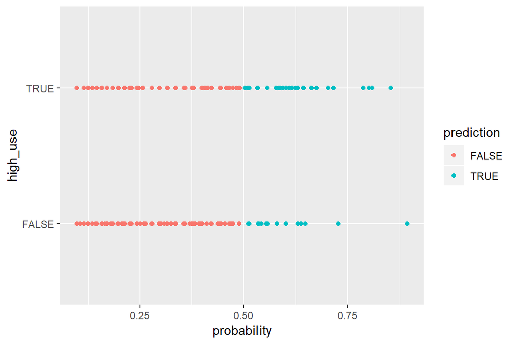

```r
g <- ggplot(alc, aes(x = probability, y = high_use, col = prediction))
g + geom_point()
```

```r
table(high_use = alc$high_use, prediction = alc$prediction) %>% prop.table %>% addmargins
```

```
##         prediction
## high_use      FALSE       TRUE        Sum
##    FALSE 0.66230366 0.03926702 0.70157068
##    TRUE  0.21465969 0.08376963 0.29842932
##    Sum   0.87696335 0.12303665 1.00000000
```

The next task at hand is accuracy and loss functions. I will compute the total proportion of inaccurately classified individuals, in other words the training error. The loss function `loss_func` is defined and called to compute the average number of wrong predictions in the (training) data.

```r
loss_func <- function(class, prob) {
  n_wrong <- abs(class - prob) > 0.5
  mean(n_wrong)
}
loss_func(class = alc$high_use, prob = alc$probability)
```

```
## [1] 0.2539267
```

The training error for this model is approximately 0.254, while the test error is calculated in the following section.

## Part 7 - Bonus: 10-fold Cross-validation

As a bonus I will perform a 10-old cross-validation on my model. This tells us the testing errors, as opposed to the training errors above.

```r
# K-fold cross-validation
library(boot)
cv <- cv.glm(data = alc, cost = loss_func, glmfit = model, K = 10)

# average number of wrong predictions in the cross validation
cv$delta[1]
```

```
## [1] 0.2670157
```

## Part 8 - Super-Bonus: Comparing the Performance of Different Logistic Regression Models

As a super-bonus I will perform cross-validation to compare the performance of different logistic regression models. I will start with the following 20 predictors: `sex`, `address`, `famsize`, `Pstatus`, `Medu`, `Fedu`, `Mjob`, `Fjob`, `guardian`, `studytime`, `failures`, `schoolsup`, `famsup`, `activities`, `higher`, `romantic`, `famrel`, `goout`, `health`, and `absences`.

```r
alc_use <- alc$alc_use
high_use <- alc$high_use
sex <- alc$sex
address <- alc$address
famsize <- alc$famsize
Pstatus <- alc$Pstatus
Medu <- alc$Medu
Fedu <- alc$Fedu
Mjob <- alc$Mjob
Fjob <- alc$Fjob
guardian <- alc$guardian
studytime <- alc$studytime
failures <- alc$failures
schoolsup <- alc$schoolsup
famsup <- alc$famsup
activities <- alc$activities
higher <- alc$higher
romantic <- alc$romantic
famrel <- alc$famrel
goout <- alc$goout
health <- alc$health
absences <- alc$absences

model_20 <- glm(high_use ~ sex + address + famsize + Pstatus + Medu + Fedu + Mjob + Fjob + guardian + studytime + failures + schoolsup + famsup + activities + higher + romantic + famrel + goout + health + absences, data = alc, family = "binomial")

probabilities <- predict(model_20, type = "response")
alc <- mutate(alc, probability = probabilities)
alc <- mutate(alc, prediction = probability > 0.5)

loss_func <- function(class, prob) {
  n_wrong <- abs(class - prob) > 0.5
  mean(n_wrong)
}
t_er_20 <- loss_func(class = alc$high_use, prob = alc$probability)
t_er_20
```

```
## [1] 0.1989529
```

```r
cv_20 <- cv.glm(data = alc, cost = loss_func, glmfit = model_20, K = 10)
ts_er_20 <- cv_20$delta[1]
ts_er_20
```

```
## [1] 0.2408377
```

Let’s see what happens when we reduce the number of predictors to 15.

I will leave out `higher`, `famsup`, `schoolsup`, `Medu` and `Fedu` from the next model, leaving me with 15 predictors.

```r
model_15 <- glm(high_use ~ sex + address + famsize + Pstatus + Mjob + Fjob + guardian + studytime + failures + activities + romantic + famrel + goout + health + absences, data = alc, family = "binomial")

probabilities <- predict(model_15, type = "response")
alc <- mutate(alc, probability = probabilities)
alc <- mutate(alc, prediction = probability > 0.5)

loss_func <- function(class, prob) {
  n_wrong <- abs(class - prob) > 0.5
  mean(n_wrong)
}
t_er_15 <- loss_func(class = alc$high_use, prob = alc$probability)
t_er_15
```

```
## [1] 0.1937173
```

```r
cv_15 <- cv.glm(data = alc, cost = loss_func, glmfit = model_15, K = 10)
ts_er_15 <- cv_15$delta[1]
ts_er_15
```

```
## [1] 0.2277487
```

Now I will reduce the number of predictors to 10.

I will leave out `famsize`, `Pstatus`, `Mjob`, `Fjob` and `romantic` from the next model, leaving me with 10 predictors.

```r
model_10 <- glm(high_use ~ sex + address + guardian + studytime + failures + activities + famrel + goout + health + absences, data = alc, family = "binomial")

probabilities <- predict(model_10, type = "response")
alc <- mutate(alc, probability = probabilities)
alc <- mutate(alc, prediction = probability > 0.5)

loss_func <- function(class, prob) {
  n_wrong <- abs(class - prob) > 0.5
  mean(n_wrong)
}
t_er_10 <- loss_func(class = alc$high_use, prob = alc$probability)
t_er_10
```

```
## [1] 0.2041885
```

```r
cv_10 <- cv.glm(data = alc, cost = loss_func, glmfit = model_10, K = 10)
ts_er_10 <- cv_10$delta[1]
ts_er_10
```

```
## [1] 0.2251309
```

Now I will reduce the number of predictors to 6.

I will take out 4 predictors (`activities`, `guardian`, `failures` and `health`).

```r
model_6 <- glm(high_use ~ sex + address + studytime + famrel + goout + absences, data = alc, family = "binomial")

probabilities <- predict(model_6, type = "response")
alc <- mutate(alc, probability = probabilities)
alc <- mutate(alc, prediction = probability > 0.5)

loss_func <- function(class, prob) {
  n_wrong <- abs(class - prob) > 0.5
  mean(n_wrong)
}
t_er_6 <- loss_func(class = alc$high_use, prob = alc$probability)
t_er_6
```

```
## [1] 0.2172775
```

```r
cv_6 <- cv.glm(data = alc, cost = loss_func, glmfit = model_6, K = 10)
ts_er_6 <- cv_6$delta[1]
ts_er_6
```

```
## [1] 0.2120419
```

I will now take out the predictors one by one, until I reach 1.

```r
model_5 <- glm(high_use ~ sex + studytime + famrel + goout + absences, data = alc, family = "binomial")

probabilities <- predict(model_5, type = "response")
alc <- mutate(alc, probability = probabilities)
alc <- mutate(alc, prediction = probability > 0.5)

loss_func <- function(class, prob) {
  n_wrong <- abs(class - prob) > 0.5
  mean(n_wrong)
}
t_er_5 <- loss_func(class = alc$high_use, prob = alc$probability)
t_er_5
```

```
## [1] 0.2172775
```

```r
cv_5 <- cv.glm(data = alc, cost = loss_func, glmfit = model_5, K = 10)
ts_er_5 <- cv_5$delta[1]
ts_er_5
```

```
## [1] 0.2225131
```

```r
model_4 <- glm(high_use ~ sex + famrel + goout + absences, data = alc, family = "binomial")

probabilities <- predict(model_4, type = "response")
alc <- mutate(alc, probability = probabilities)
alc <- mutate(alc, prediction = probability > 0.5)

loss_func <- function(class, prob) {
  n_wrong <- abs(class - prob) > 0.5
  mean(n_wrong)
}
t_er_4 <- loss_func(class = alc$high_use, prob = alc$probability)
t_er_4
```

```
## [1] 0.2041885
```

```r
cv_4 <- cv.glm(data = alc, cost = loss_func, glmfit = model_4, K = 10)
ts_er_4 <- cv_4$delta[1]
ts_er_4
```

```
## [1] 0.2120419
```

```r
model_3 <- glm(high_use ~ sex + goout + absences, data = alc, family = "binomial")

probabilities <- predict(model_3, type = "response")
alc <- mutate(alc, probability = probabilities)
alc <- mutate(alc, prediction = probability > 0.5)

loss_func <- function(class, prob) {
  n_wrong <- abs(class - prob) > 0.5
  mean(n_wrong)
}
t_er_3 <- loss_func(class = alc$high_use, prob = alc$probability)
t_er_3
```

```
## [1] 0.2094241
```

```r
cv_3 <- cv.glm(data = alc, cost = loss_func, glmfit = model_3, K = 10)
ts_er_3 <- cv_3$delta[1]
ts_er_3
```

```
## [1] 0.2225131
```

```r
model_2 <- glm(high_use ~ sex + absences, data = alc, family = "binomial")

probabilities <- predict(model_2, type = "response")
alc <- mutate(alc, probability = probabilities)
alc <- mutate(alc, prediction = probability > 0.5)

loss_func <- function(class, prob) {
  n_wrong <- abs(class - prob) > 0.5
  mean(n_wrong)
}
t_er_2 <- loss_func(class = alc$high_use, prob = alc$probability)
t_er_2
```

```
## [1] 0.2565445
```

```r
cv_2 <- cv.glm(data = alc, cost = loss_func, glmfit = model_2, K = 10)
ts_er_2 <- cv_2$delta[1]
ts_er_2
```

```
## [1] 0.2696335
```

```r
model_1 <- glm(high_use ~ sex, data = alc, family = "binomial")

probabilities <- predict(model_1, type = "response")
alc <- mutate(alc, probability = probabilities)
alc <- mutate(alc, prediction = probability > 0.5)

loss_func <- function(class, prob) {
  n_wrong <- abs(class - prob) > 0.5
  mean(n_wrong)
}
t_er_1 <- loss_func(class = alc$high_use, prob = alc$probability)
t_er_1
```

```
## [1] 0.2984293
```

```r
cv_1 <- cv.glm(data = alc, cost = loss_func, glmfit = model_1, K = 10)
ts_er_1 <- cv_1$delta[1]
ts_er_1
```

```
## [1] 0.2984293
```

Finally, I drew a simple graph that displays the trends of both training and testing errors by the number of predictors in the model.

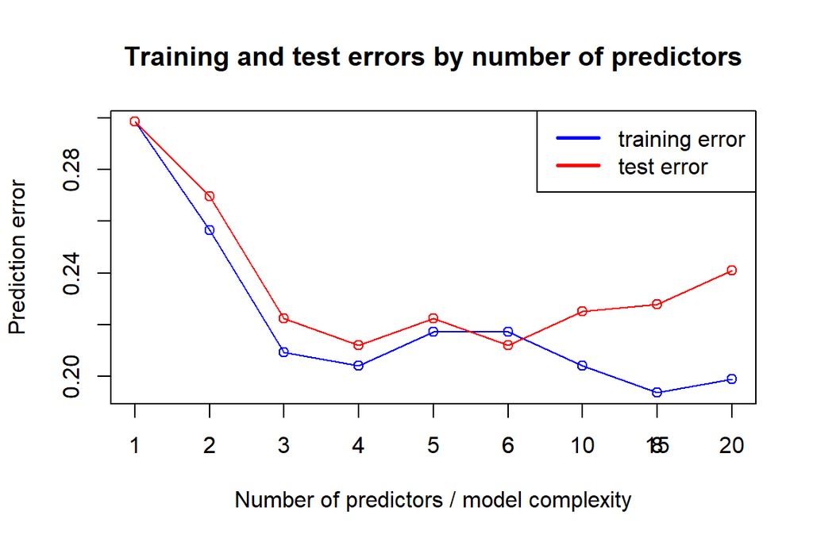

```r
t_er<-c(t_er_1,t_er_2,t_er_3,t_er_4,t_er_5,t_er_6,t_er_10,t_er_15,t_er_20)

ts_er<-c(ts_er_1,ts_er_2,ts_er_3,ts_er_4,ts_er_5,ts_er_6,ts_er_10,ts_er_15,ts_er_20)

plot(t_er, type="o", col="blue", xlab="Number of predictors / model complexity", ylab="Prediction error")
lines(ts_er, type="o", col="red")
axis(1, at=1:9, lab=c("1","2","3","4","5","6","10","15","20"))
title(main="Training and test errors by number of predictors")
legend("topright", c("training error","test error"),lty=c(1,1), lwd=c(2.5,2.5),col=c("blue","red"))
```

To the left of the graph are situations where the model is low in complexity and has high bias and low variance. To the right of the graph are situations where the model is high in complexity and has low bias and high variance.

That’s all for this week - I’m already looking forward to next week’s tasks!

# 4. Clustering and Classification

The topics of this week - clutering and classification - are visual tools for the exploration of statistical data. Clustering means that some data points are closer to each other than some other points: they are clustered. Once we have clustered successfully, we can try to classify new observations to these clusters, thus validating the results of clustering.

*Below are all the codes, my interpretations and explanations for this week’s data analysis exercises.*

## Part 1 - General Housekeeping

As in last week, I created a new RMarkdown file and save it as an empty file named ‘chapter4.Rmd’. Then I included this file as a child file in my ‘index.Rmd’ file, and as a result you are now reading this.

I also accessed some packages that I might need later.

```r
library(ggplot2); library(GGally); library(corrplot); library(tidyr); library(dplyr)
```

## Part 2 - Loading the Boston data

To load and explore the Boston data, I first needed to access the MASS package, and then load the “Boston” data. Below is the structure and summary of the data, and also a matrix of the variables.

```r
# access the MASS package
library(MASS)
# load the data
data("Boston")

# explore the dataset
str(Boston)
```

```
## 'data.frame':    506 obs. of  14 variables:
##  $ crim   : num  0.00632 0.02731 0.02729 0.03237 0.06905 ...
##  $ zn     : num  18 0 0 0 0 0 12.5 12.5 12.5 12.5 ...
##  $ indus  : num  2.31 7.07 7.07 2.18 2.18 2.18 7.87 7.87 7.87 7.87 ...
##  $ chas   : int  0 0 0 0 0 0 0 0 0 0 ...
##  $ nox    : num  0.538 0.469 0.469 0.458 0.458 0.458 0.524 0.524 0.524 0.524 ...
##  $ rm     : num  6.58 6.42 7.18 7 7.15 ...
##  $ age    : num  65.2 78.9 61.1 45.8 54.2 58.7 66.6 96.1 100 85.9 ...
##  $ dis    : num  4.09 4.97 4.97 6.06 6.06 ...
##  $ rad    : int  1 2 2 3 3 3 5 5 5 5 ...
##  $ tax    : num  296 242 242 222 222 222 311 311 311 311 ...
##  $ ptratio: num  15.3 17.8 17.8 18.7 18.7 18.7 15.2 15.2 15.2 15.2 ...
##  $ black  : num  397 397 393 395 397 ...
##  $ lstat  : num  4.98 9.14 4.03 2.94 5.33 ...
##  $ medv   : num  24 21.6 34.7 33.4 36.2 28.7 22.9 27.1 16.5 18.9 ...
```

The Boston data set is a data frame with 506 observations of 14 variables. The data examines housing values in the suburbs of Boston. The variables are all numeric, with two variables being integer types.

A link to details about the Boston dataset can be seen [here](https://stat.ethz.ch/R-manual/R-devel/library/MASS/html/Boston.html).

Here is the source of the data: